# 7. Motores de 4T (parte 3)

## Arranque de un motor 4T

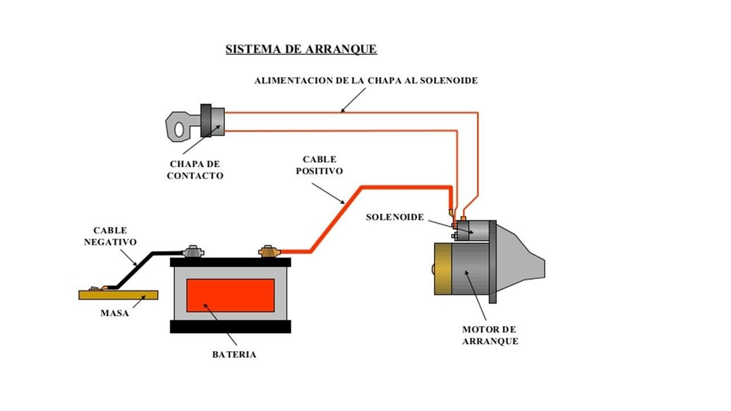

Al girar la llave la batería enciende el motor de arranque - Fuente: Coches.com

El arranque es el **momento inicial en el que el motor comienza a girar por sí mismo**, pasando de estar detenido a funcionar de forma continua.

Para cualquier motor de 4T, naftero o gasolero, el proceso de arranque es el siguiente:

1. **Se gira la llave o se presiona el botón de encendido.**
2. La **batería** envía electricidad al **motor de arranque**.
3. El motor de arranque hace girar el **cigüeñal**, lo que mueve los pistones.
4. El motor realiza los primeros ciclos. Una vez que uno de los cilindros genera **combustión real**, el motor empieza a girar solo.
5. El motor de arranque se **desconecta automáticamente**.

[Aquí](https://www.youtube.com/watch?v=a8Q5X9nHYAI) puedes ver una explicación breve y gráfica.

## Encendido de un motor 4T

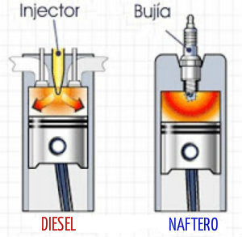

El naftero necesita chispa mientras que el gasolero se autoenciende por la compresión

Una vez que el motor arranca hay que lograr que se mantenga en funcionamiento por sí mismo. Para ésto hay que lograr que la mezcla aire-combustible se encienda en un momento preciso dentro de cada cilindro. Este es el objetivo del **sistema de encendido** y funciona distinto según se trate de un motor naftero o gasolero (diesel).

## Encendido de un motor 4T naftero

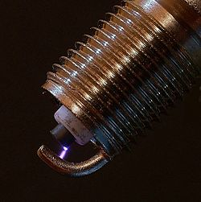

Chispa eléctrica en una bujía - Fuente: Wikipedia

[Aquí](https://www.youtube.com/watch?v=CqlG89cHAnk) puedes ver una explicación.

Básicamente el motor naftero necesita de la chispa de la bujía para encender la mezcla de aire y combustible. Esta se produce gracias a la electricidad de alta tensión que llega a a la bujía en el momento justo. El momento justo es determinado por:

- **un distribuidor** mecánico en motores más antiguos,
- o por una computadora llamada **ECU** (Electronic control unit) en motores más modernos.

### ¿Cómo es el sistema con distribuidor?

El distribuidor, usado en motores antiguos, es un dispositivo que:

- Gira con el motor.
- Abre y cierra un contacto llamado ruptor o “platino”.
- Manda corriente a la bujía correcta en el momento justo.
- Esta sincronizado con el cigüeñal.

Al ser un sistema mecánico es sensible al desgaste, la humedad y la suciedad.

### ¿Cómo es el sistema con ECU?

Hoy en día, la mayoría de los vehículos usan un sistema totalmente electrónico, controlado por una ECU (Unidad de Control Electrónico).

**¿Qué es la ECU?**

La ECU es una computadora del motor. Controla muchas funciones, como:

- El encendido (cuándo generar la chispa en cada cilindro).
- La inyección de combustible.

La ECU recibe señales de sensores (por ejemplo, del cigüeñal y del árbol de levas) y decide:

- Qué bujía encender.
- En qué momento exacto hacerlo.

El sistema es más preciso, más confiable y requiere menos mantenimiento.

## Actividad 1

Cuando un motor 4T naftero está apagado y quieto debe empezar a moverse para que se produzca la admisión y el resto de las etapas hasta la primer chispa. Explique con sus palabras (escríbalas) como se logra esto. En tu explicación tiene que aparecer la palabra “motor de arranque”.

## Encendido en motor 4T gasolero (Diesel)

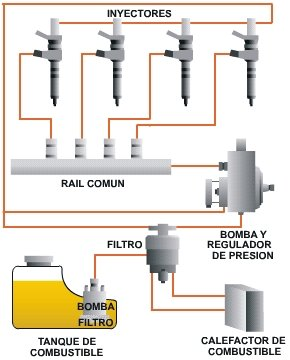

Sistema common rail - Fuente: tecnologia-automovil.com

Básicamente este motor no requiere ninguna chispa por que la mezcla aire-combustible se enciende sola al calentarse por la compresión. El combustible es inyectado por inyectores siendo el sistema “Common rail” uno muy común.

Paso a paso del arranque en un motor diesel:

- Girás la llave (o presionás el botón de encendido).
- La batería alimenta al motor de arranque.
- El motor de arranque hace girar el cigüeñal → los pistones se mueven.
- Si el motor está frío, las bujías de precalentamiento calientan el aire dentro de los cilindros.
- El pistón comprime el aire → se calienta mucho.
- En ese momento, el inyector inyecta gasoil → se autoinflama.
- El motor ahora genera su propia energía y sigue girando sin ayuda del motor de arranque.

## Actividad 2

(Se cambió la actividad original que se dió en clase por resultar demasiado complejo el esquema de un inyector diesel por dentro. De todos modos si alguien lo hizo puede dejarlo y es válido)

Observa este [video](https://www.youtube.com/watch?v=qgTlBBWUM1Y) que muestra como funciona un sistema de inyección moderno en los motores diesel. Se llama “Common rail”. Luego escribe una explicación de como funciona este sistema asegurándote de usar las siguientes frases palabras en tu explicación: “common rail (riel común)”, “ECU”, “alta presión”, “inyectores”, “acelerador”.